# MIMIC-III Tutorial Part 1: Data Extraction

# 2 Exploring individual variables

Next, we can explore the individual variables collected as part of the SIRS scoring system. First, I’ll create a `plotHistogram()` function, which then can be called for each variable. I’ll also create a `compareDistribution()` function to plot the kernel density estimate (KDE) by group.

```r
# Plot histogram, given the dataframe, the x-data, and the title.
plotHistogram <- function(d, xdata, title){
  fig <- ggplot(data=d, aes(x=d[,xdata])) +
    geom_histogram() +
    ggtitle(sprintf('Histogram of %s', title)) + xlab(title)
}

# Plot density plots of temperature, given the dataframe, the x-data, grouping variable, and the title.
compareDistribution <- function(d, xdata, grouping_var, title){
  fig <- ggplot(data=d, aes(x=d[,xdata], fill=d[,grouping_var])) +
    geom_density(alpha=0.5) +
    scale_fill_discrete(name='Diagnosed sepsis') +
    ylab('Kernel Density Estimate') +
    ggtitle(sprintf('Grouped KDE of %s', title)) + xlab(title)
}
```

## 2.1 Descriptive Statistics

First, we’ll generate some descriptive statistics for each variable using the `describe()` function from the `psych` package.

```r
statistics_of_interest = c('n', 'mean', 'sd', 'skew', 'kurtosis', 'median', 'IQR', 'min', 'max', 'range', 'se')
tbl <- describe( cohort_data[, -which(names(cohort_data) %in% c('subject_id', 'icd9_code', 'septic'))], IQR=T) # get rid of ID vars
kable(t(tbl[,statistics_of_interest]), digits=2, caption='Descriptive Statistics for Total Cohort') %>%
  kable_styling(bootstrap_options='striped')
```

Descriptive Statistics for Total Cohort

|  | temperature | heartrate | resprate | paco2 | wbc |
| --- | --- | --- | --- | --- | --- |
| n | 3119.00 | 3119.00 | 3119.00 | 3119.00 | 3119.00 |
| mean | 36.76 | 87.36 | 18.52 | 42.35 | 12.00 |
| sd | 0.95 | 18.68 | 6.00 | 12.02 | 7.81 |
| skew | -0.20 | 0.51 | 1.16 | 2.13 | 5.99 |
| kurtosis | 1.65 | 0.44 | 3.20 | 8.75 | 75.10 |
| median | 36.78 | 86.00 | 18.00 | 40.00 | 10.50 |
| IQR | 1.17 | 24.00 | 8.00 | 12.00 | 7.10 |
| min | 30.70 | 35.00 | 1.00 | 11.00 | 1.10 |
| max | 40.44 | 173.00 | 68.00 | 143.00 | 145.20 |
| range | 9.74 | 138.00 | 67.00 | 132.00 | 144.10 |
| se | 0.02 | 0.33 | 0.11 | 0.22 | 0.14 |

## 2.2 Temperature

The first variable on our list is temperature. We’ll plot the histogram of the overall temperature and the the kernel density estimation of the two groups next to it.

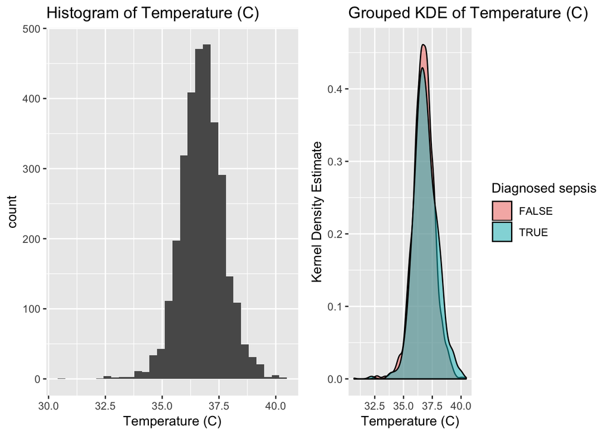

```r
ggarrange(
  plotHistogram(cohort_data, 'temperature', 'Temperature (C)'),
  compareDistribution(cohort_data, 'temperature', 'septic', 'Temperature (C)'),
  ncol=2
)
```

## 2.3 Heart Rate

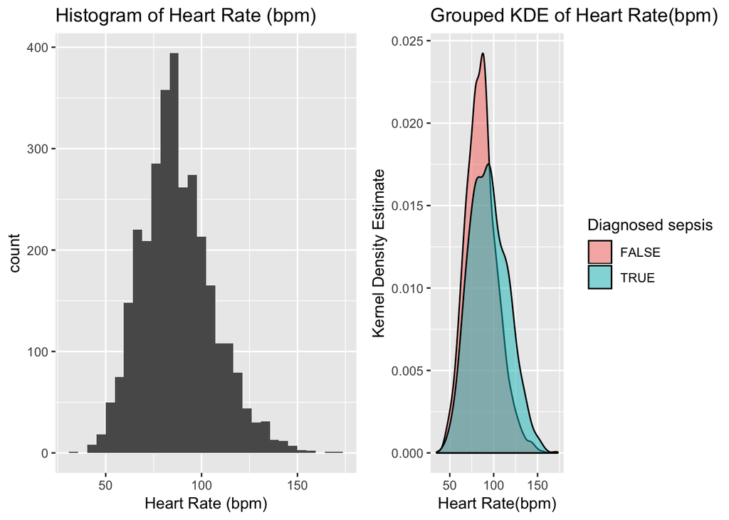

```r
ggarrange(
  plotHistogram(cohort_data, 'heartrate', 'Heart Rate (bpm)'),
  compareDistribution(cohort_data, 'heartrate', 'septic', 'Heart Rate(bpm)'),
  ncol=2
)
```

## 2.4 Respiratory Rate

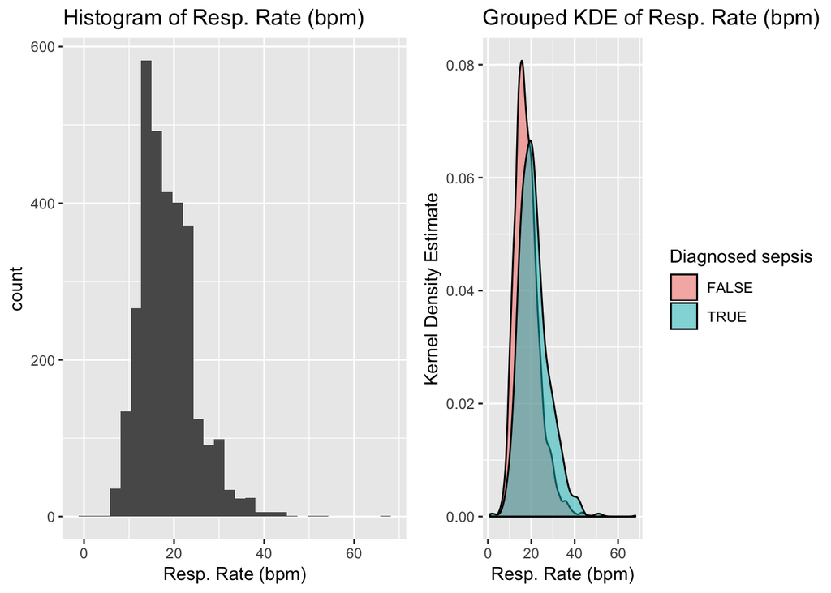

```r
ggarrange(
  plotHistogram(cohort_data, 'resprate', 'Resp. Rate (bpm)'),
  compareDistribution(cohort_data, 'resprate', 'septic', 'Resp. Rate (bpm)'),
  ncol=2
)
```

## 2.5 Partial Pressure of Arterial CO_2_

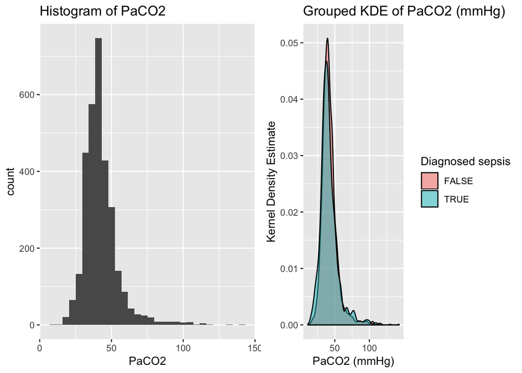

```r
ggarrange(
  plotHistogram(cohort_data, 'paco2', 'PaCO2'),
  compareDistribution(cohort_data, 'paco2', 'septic', 'PaCO2 (mmHg)'),
  ncol=2
)
```

## 2.6 White Blood Cell Count

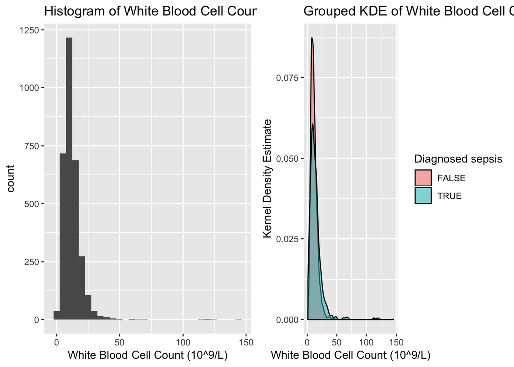

```r
ggarrange(
  plotHistogram(cohort_data, 'wbc', 'White Blood Cell Count (10^9/L)'),
  compareDistribution(cohort_data, 'wbc', 'septic', 'White Blood Cell Count (10^9/L)'),
  ncol=2
)
```

# 3 Things to try on your own:

1. Which, if any, variables in the SIRS score have a significant difference between septic and non-septic patients?
2. Calculate SIRS scores for all patients.
3. How well does the SIRS score differentiate between septic and non-septic patients?
4. Can you create a better classifier using this limited dataset?